# Exercise 1 — Basic Maps and Graphs in R

BSTA 374 · 12 points · Due Thursday, September 10, 2026, 11:59 pm

Author

Ahmad Tariq · Lehigh University

Published

September 17, 2026

## What this exercise is

Your first graded work in this course. It covers the first two weeks: reading spatial data with `sf`, understanding what a coordinate reference system is and moving between them, and producing honest choropleth and point maps with both `ggplot2` and `tmap`.

**No data to download.** Everything runs on the North Carolina SIDS data that ships inside the `sf` package, so your analysis will reproduce on my machine exactly as it does on yours — which is the point.

Each part ends with **starting code**. Copy it, fill in the blanks marked `______`, and adapt it. It is scaffolding, not a solution: the mechanical lines are given so that your time goes into the parts that require judgement.

**ImportantSubmission**

Submit **one file** to Course Site:

- `LASTNAME_FI_Exercise1.qmd` — the source

Example: `DELMELLE_EM_Exercise1.qmd`. Put your name in the document header.

**Due Thursday, September 10, 2026 at 11:59 pm.** Late work loses 20% per day unless you arrange something with me in advance.

**WarningReproducibility is graded**

Before you submit: restart R (`Ctrl/Cmd + Shift + F10`) and render the document from a clean session. If it does not run start to finish, it is incomplete — regardless of how good the maps are. This is the habit that matters most, and we start enforcing it now.

```r
library(sf)
library(dplyr)
library(ggplot2)
library(tmap)
# add anything else you use -- and load it here, not halfway down

nc <- st_read(system.file("shape/nc.shp", package = "sf"), quiet = TRUE)
```

## Part A — Read and describe the data (2 points)

Answer each in **one or two sentences of prose**, outside the code chunks, and show the code you used to find out.

1. How many features does `nc` contain, and what does one row represent?

```r
nrow(nc)
```

```
[1] 100
```

```r
names(nc)
```

```
 [1] "AREA"      "PERIMETER" "CNTY_"     "CNTY_ID"   "NAME"      "FIPS"
 [7] "FIPSNO"    "CRESS_ID"  "BIR74"     "SID74"     "NWBIR74"   "BIR79"
[13] "SID79"     "NWBIR79"   "geometry"
```

```r
nc
```

```
Simple feature collection with 100 features and 14 fields
Geometry type: MULTIPOLYGON
Dimension:     XY
Bounding box:  xmin: -84.32385 ymin: 33.88199 xmax: -75.45698 ymax: 36.58965
Geodetic CRS:  NAD27
First 10 features:
    AREA PERIMETER CNTY_ CNTY_ID        NAME  FIPS FIPSNO CRESS_ID BIR74 SID74
1  0.114     1.442  1825    1825        Ashe 37009  37009        5  1091     1
2  0.061     1.231  1827    1827   Alleghany 37005  37005        3   487     0
3  0.143     1.630  1828    1828       Surry 37171  37171       86  3188     5
4  0.070     2.968  1831    1831   Currituck 37053  37053       27   508     1
5  0.153     2.206  1832    1832 Northampton 37131  37131       66  1421     9
6  0.097     1.670  1833    1833    Hertford 37091  37091       46  1452     7
7  0.062     1.547  1834    1834      Camden 37029  37029       15   286     0
8  0.091     1.284  1835    1835       Gates 37073  37073       37   420     0
9  0.118     1.421  1836    1836      Warren 37185  37185       93   968     4
10 0.124     1.428  1837    1837      Stokes 37169  37169       85  1612     1
   NWBIR74 BIR79 SID79 NWBIR79                       geometry
1       10  1364     0      19 MULTIPOLYGON (((-81.47276 3...
2       10   542     3      12 MULTIPOLYGON (((-81.23989 3...
3      208  3616     6     260 MULTIPOLYGON (((-80.45634 3...
4      123   830     2     145 MULTIPOLYGON (((-76.00897 3...
5     1066  1606     3    1197 MULTIPOLYGON (((-77.21767 3...
6      954  1838     5    1237 MULTIPOLYGON (((-76.74506 3...
7      115   350     2     139 MULTIPOLYGON (((-76.00897 3...
8      254   594     2     371 MULTIPOLYGON (((-76.56251 3...
9      748  1190     2     844 MULTIPOLYGON (((-78.30876 3...
10     160  2038     5     176 MULTIPOLYGON (((-80.02567 3...
```

The nc dataset contains 100 features, and each row represents one county in North Carolina.

2. What geometry type is stored? Why is it that type rather than `POLYGON`?

```r
table(st_geometry_type(nc))
```

```
          GEOMETRY              POINT         LINESTRING            POLYGON
                 0                  0                  0                  0
        MULTIPOINT    MULTILINESTRING       MULTIPOLYGON GEOMETRYCOLLECTION
                 0                  0                100                  0
    CIRCULARSTRING      COMPOUNDCURVE       CURVEPOLYGON         MULTICURVE
                 0                  0                  0                  0
      MULTISURFACE              CURVE            SURFACE  POLYHEDRALSURFACE
                 0                  0                  0                  0
               TIN           TRIANGLE
                 0                  0
```

The geometry type stored is MULTIPOLYGON. It is used instead of POLYGON because some North Carolina counties, especially along the coast, have separate disconnected pieces such as barrier islands that are still part of the same county.

3. What coordinate reference system is the data in? Give its name, say whether it is geographic or projected, and say how you found out.

```r
st_crs(nc)
```

```
Coordinate Reference System:
  User input: NAD27
  wkt:
GEOGCRS["NAD27",
    DATUM["North American Datum 1927",
        ELLIPSOID["Clarke 1866",6378206.4,294.978698213898,
            LENGTHUNIT["metre",1]]],
    PRIMEM["Greenwich",0,
        ANGLEUNIT["degree",0.0174532925199433]],
    CS[ellipsoidal,2],
        AXIS["latitude",north,
            ORDER[1],
            ANGLEUNIT["degree",0.0174532925199433]],
        AXIS["longitude",east,
            ORDER[2],
            ANGLEUNIT["degree",0.0174532925199433]],
    ID["EPSG",4267]]
```

```r
st_crs(nc)$input
```

```
[1] "NAD27"
```

```r
st_is_longlat(nc)
```

```
[1] TRUE
```

The data use the NAD27 coordinate reference system, which is a geographic CRS using longitude and latitude in degrees. I found this using st_crs(nc), st_crs(nc)$input, and st_is_longlat(nc), which returned TRUE.

4. In your own words, what do `BIR74` and `SID74` measure? Why does having both matter more than having either one alone?

```r
?nc
```

BIR74 measures the number of live births from 1974-1978, while SID74 measures the number of sudden infant deaths during the same period. Having both is important because the number of births gives context for the number of deaths and allows us to calculate a SIDS rate, making comparisons between counties more meaningful.

## Part B — Coordinate reference systems (2 points)

1. Transform `nc` to **EPSG:32119** (NAD83 / North Carolina State Plane, in metres) and store it as a **new object**. Do not overwrite `nc` — you need both.

```r
nc_proj <- st_transform(nc, 32119)
```

I transformed nc to EPSG:32119 and stored the projected data in a new object called nc_proj.

2. Plot the counties **before and after**, near enough to each other that a reader can compare them. One or two sentences on what visibly changed.

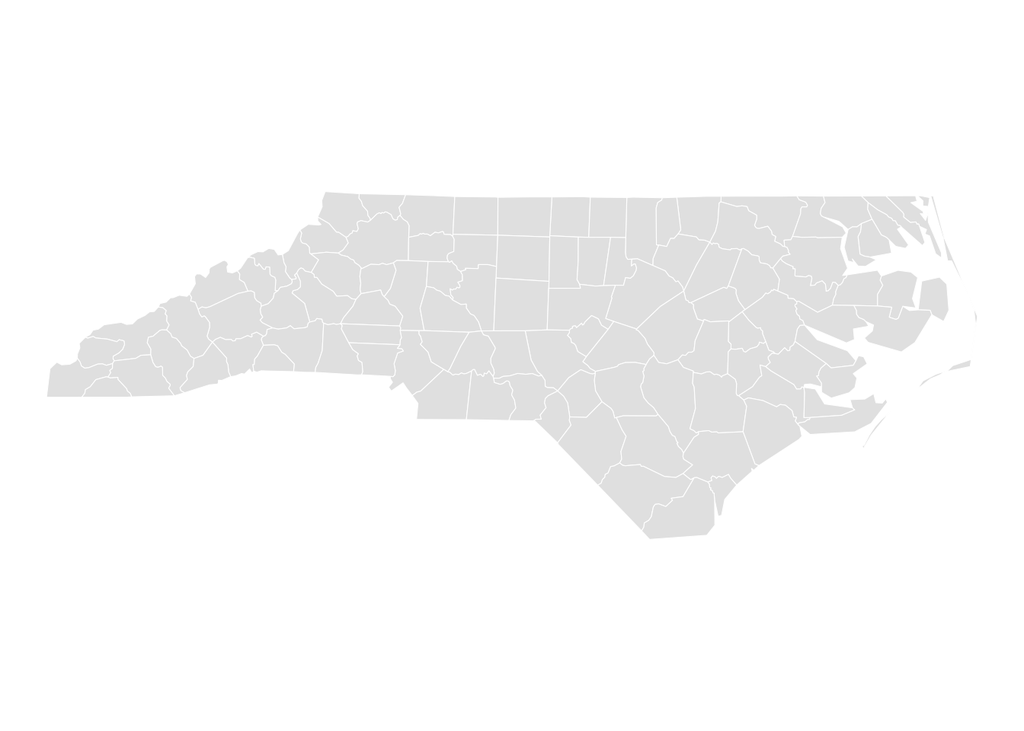

```r
p1 <- ggplot(nc)      + geom_sf(fill = "grey90", colour = "white") + theme_void()
p2 <- ggplot(nc_proj) + geom_sf(fill = "grey90", colour = "white") + theme_void()

p1
```

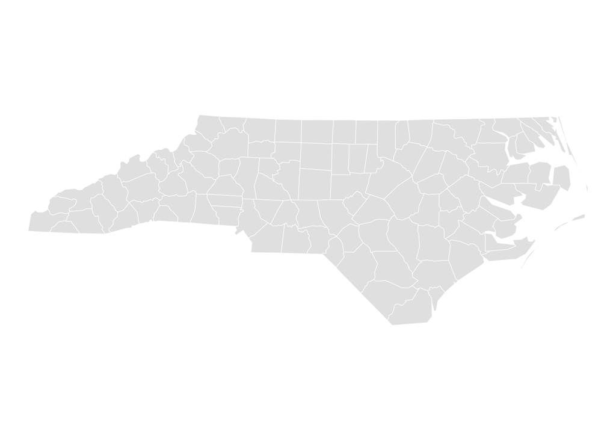

```r
p2
```

3. Compute the area of every county in **square kilometres**, using the projected version. Report the five largest.

```r
nc_proj <- nc_proj |>
  mutate(area_km2 = as.numeric(units::set_units(st_area(nc_proj), km^2)))

nc_proj |>
  st_drop_geometry() |>
  slice_max(area_km2, n = 5) |>
  select(NAME, area_km2)
```

```
      NAME area_km2
1 Columbus 2450.349
2  Robeson 2439.238
3  Sampson 2437.410
4   Bladen 2288.424
5     Wake 2194.261
```

The five largest counties by area are Columbus (2450.35 km^2), Robeson (2439.24 km^2), Sampson (2437.41 km^2), Bladen (2288.42 km^2), and Wake (2194.26 km^2).

4. Now compute areas from the *unprojected* object as well. Compare the two sets of numbers and explain, in two or three sentences, what `sf` did and why the projected version is the one you would report in a paper.

```r
nc_unproj <- nc |>
  mutate(area_km2 = as.numeric(units::set_units(st_area(nc), km^2)))

nc_unproj |>
  st_drop_geometry() |>
  slice_max(area_km2, n = 5) |>
  select(NAME, area_km2)
```

```
      NAME area_km2
1 Columbus 2450.831
2  Robeson 2439.935
3  Sampson 2438.121
4   Bladen 2289.053
5     Wake 2194.374
```

The areas calculated from the unprojected and projected data are very close but not exactly the same, with Columbus County measuring 2450.831 km² unprojected compared with 2450.349 km² projected. For the unprojected data, sf calculated area using the curved Earth surface, while EPSG:32119 represents North Carolina on a projected flat surface in metres. I would report the projected areas because the North Carolina State Plane projection is designed for accurate area and distance measurements within the state.

**Note**

Step 4 will not give you an error, and the two sets of numbers will be close but not identical. That is the interesting part — the question is which *surface* each answer refers to.

## Part C — Choropleth maps (5 points)

This is the largest part of the exercise, and it is as much about judgement as about code. 1. Add a column giving the **SIDS rate per 1,000 live births** for 1974–78.

```r
nc <- nc |>
  mutate(rate74 = 1000 * SID74 / BIR74)
```

The rate74 variable is added as a new column that gives the number of SIDS deaths per 1,000 live births for each county from 1974-1978.

2. Make a choropleth of the **raw counts** (`SID74`) and one of the **rate**, using `ggplot2`. Then write three or four sentences explaining why the two maps disagree, and which one you would put in front of a health department, and why.

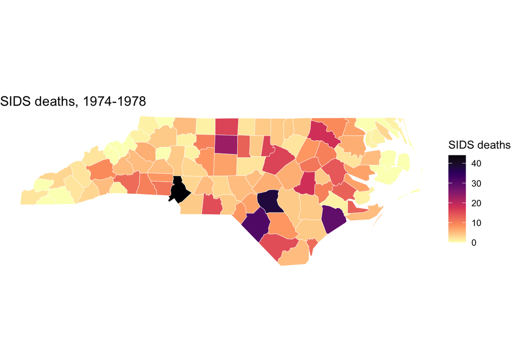

```r
#Raw count:
ggplot(nc) +
  geom_sf(aes(fill = SID74), colour = "white", linewidth = 0.15)+
  scale_fill_viridis_c(option = "magma", direction = -1, name = "SIDS deaths") +
  labs(title = "SIDS deaths, 1974-1978") +
  theme_void()
```

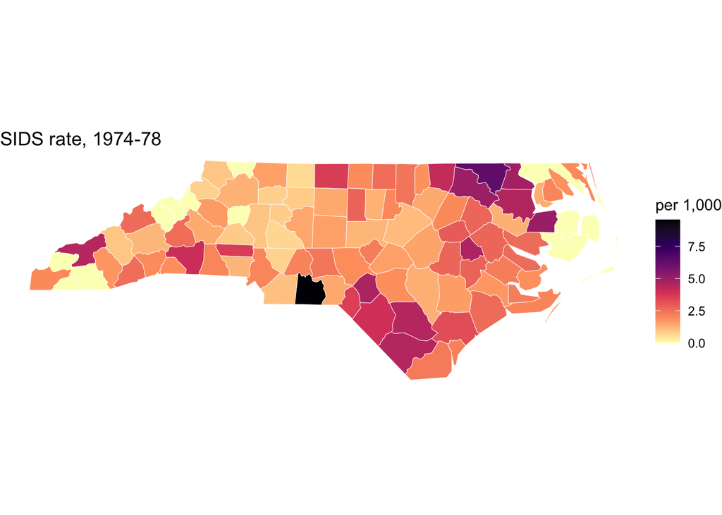

```r
#SIDS rate:
ggplot(nc) +
  geom_sf(aes(fill = rate74), colour = "white", linewidth = 0.15) +
  scale_fill_viridis_c(option = "magma", direction = -1, name = "per 1,000") +
  labs(title = "SIDS rate, 1974-78") +
  theme_void()
```

The two maps show different patterns because the raw SIDS counts are influenced by the number of births in each county. Counties with more births may have more SIDS deaths even when the risk of SIDS is not especially high. The rate accounts for the number of live births, making comparisons between counties with different population sizes more meaningful. I would present the rate map to a health department because it better represents differences in SIDS risk across counties.

3. Rebuild the rate map using **`tmap`**. Same information, other package.

```r
tmap_mode("plot")
```

```
ℹ tmap modes "plot" - "view"
ℹ toggle with `tmap::ttm()`
```

```
[plot mode] fit legend/component: Some legend items or map compoments do not
fit well, and are therefore rescaled.
ℹ Set the tmap option `component.autoscale = FALSE` to disable rescaling.
```

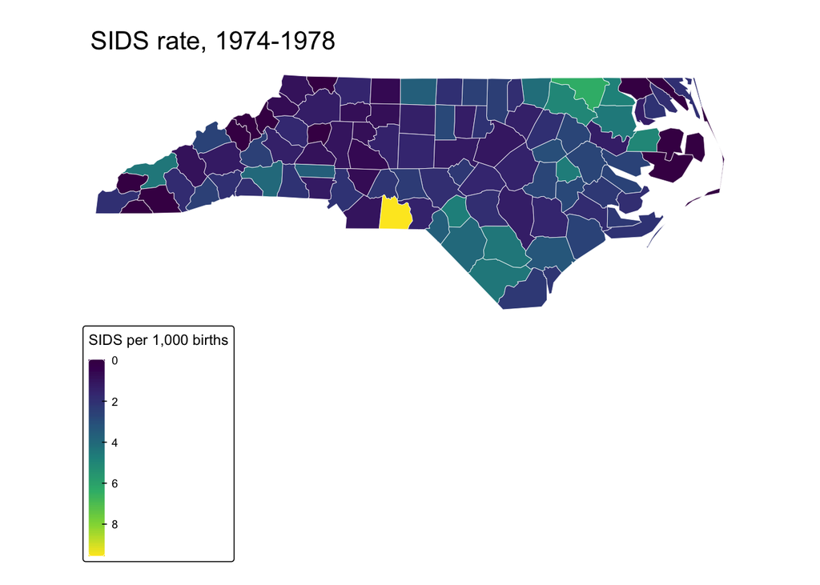

```r
tm_shape(nc) +
  tm_polygons(
    fill = "rate74",
    fill.scale = tm_scale_continuous(values = "viridis"),
    fill.legend = tm_legend(title = "SIDS per 1,000 births"),
    col = "white",
    lwd = 0.4
  ) +
  tm_title("SIDS rate, 1974-1978") +
  tm_layout(frame = FALSE)
```

The tmap shows the same county level SIDS rate as the ggplot2 map with higher values concentrated in a smaller number of counties and lower values across much of the state. Using a continuous color scale preserves the variation in SIDS rates while presenting the same information using a different mapping package.

4. Vary the **class intervals** on the rate map: produce it at least three ways — for instance equal intervals, quantiles, and Jenks natural breaks. Two or three sentences on how much the apparent geography of risk changes. Name the classification you would defend, and say why.

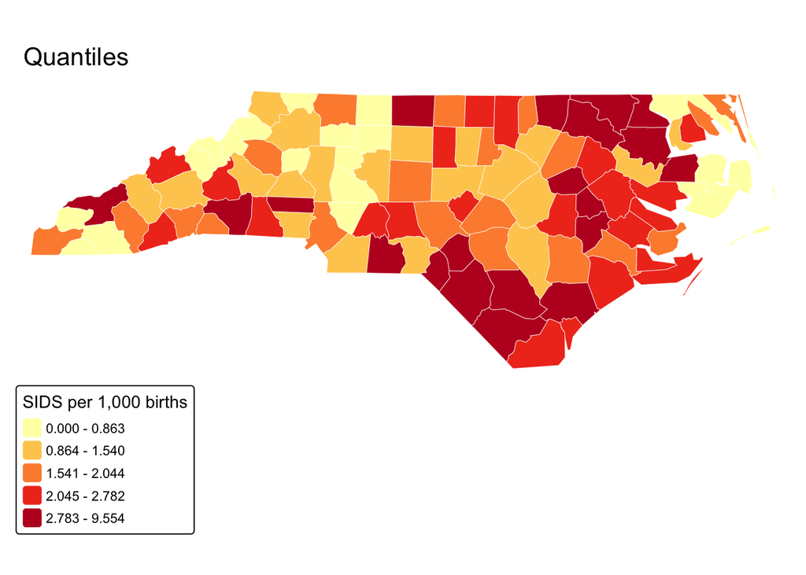

```r
tm_shape(nc) +
  tm_polygons(
    fill = "rate74",
    fill.scale = tm_scale_intervals(style = "quantile", n = 5, values = "brewer.yl_or_rd"),
    fill.legend = tm_legend(title = "SIDS per 1,000 births"),
    col = "white",
    lwd = 0.4
  ) +
  tm_title("Quantiles") +
  tm_layout(frame = FALSE)
```

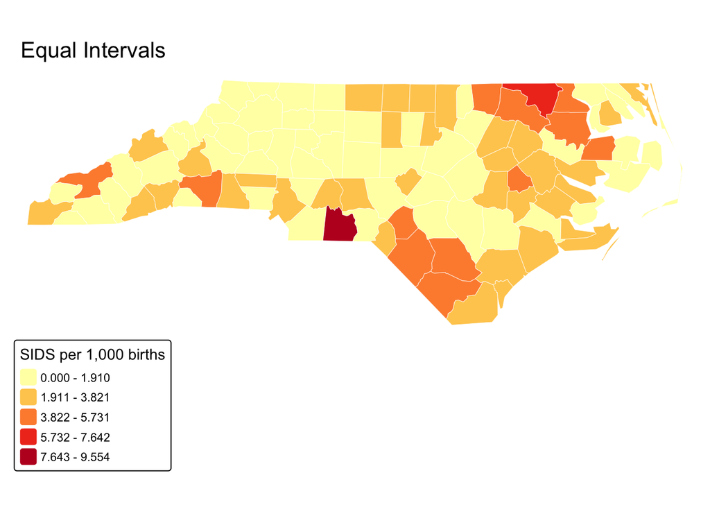

```r
tm_shape(nc) +
  tm_polygons(
    fill = "rate74",
    fill.scale = tm_scale_intervals(style = "equal", n = 5, values = "brewer.yl_or_rd"),
    fill.legend = tm_legend(title = "SIDS per 1,000 births"),
    col = "white",
    lwd = 0.4
  ) +
  tm_title("Equal Intervals") +
  tm_layout(frame = FALSE)
```

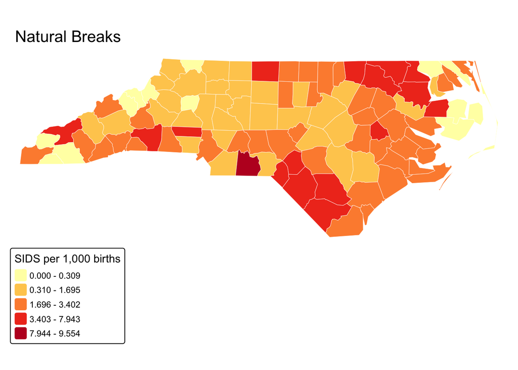

```r
tm_shape(nc) +
  tm_polygons(
    fill = "rate74",
    fill.scale = tm_scale_intervals(
      style = "fisher",
      n = 5,
      values = "brewer.yl_or_rd"
    ),
    fill.legend = tm_legend(title = "SIDS per 1,000 births"),
    col = "white",
    lwd = 0.4
  ) +
  tm_title("Natural Breaks") +
  tm_layout(frame = FALSE)
```

The apparent geography of SIDS risk changes quite a bit depending on the classification method. Equal intervals place most counties in the lower classes and make only a few extreme counties stand out, while quantiles spread counties more evenly across the five classes and natural breaks emphasize groups that occur naturally in the data. I would defend the quantile classification because it makes regional differences easier to compare across the state, although it can place counties with similar rates into different classes.

**TipWhat earns full marks here**

Not the prettiest map — the map whose choices you can defend. A student who picks quantiles and explains the trade-off in two clear sentences scores higher than one who picks Jenks because it looked nicer.

5. Every map you submit must have a **legend with units**, a **title**, thin boundaries that do not overwhelm the fill, and a **perceptually uniform, colour-blind-safe palette**. State in one sentence which palette you chose and why, including whether dark means high or low.

I used the color blind safe sequential palettes throughout with magma for the ggplot2 maps, viridis for the continuous tmap map, and YlOrRd for the classified maps, where darker colours represent higher values in the magma and YlOrRd maps and darker colours represent lower values in the viridis map.

**WarningA note on `tmap` versions**

`tmap` changed its argument names in version 4. If an example you find online uses `tm_polygons(col = ...)` or `style = ...` directly and yours errors, check `packageVersion("tmap")` and read the help page rather than guessing. The code above is written for version 4.

## Part D — A point layer (2 points)

1. Look up the approximate longitude and latitude of **four cities in North Carolina** and build a small table holding the name and the two coordinates. Cite where you got the coordinates.

```r
cities <- tibble(
  name = c("Asheville", "Charlotte", "Raleigh", "Greenville"),
  lon  = c(-82.551491, -80.843124, -78.638176, -77.366356),
  lat  = c(35.595058, 35.227085, 35.779591, 35.612659)
)
```

The approximate coordinates for Asheville, Charlotte, Raleigh, and Greenville were obtained from a LatLong.net’s finder list [https://www.latlong.net/.]

2. Turn that table into an `sf` object with the correct CRS. State which EPSG code you used and why.

```r
cities_sf <- cities |>
  st_as_sf(coords = c("lon", "lat"), crs = 4326)
```

I used EPSG:4326 because the city coordinates are longitude and latitude values in degrees using the WGS84 reference system.

3. Plot the four cities **on top of** your rate choropleth, labelled legibly.

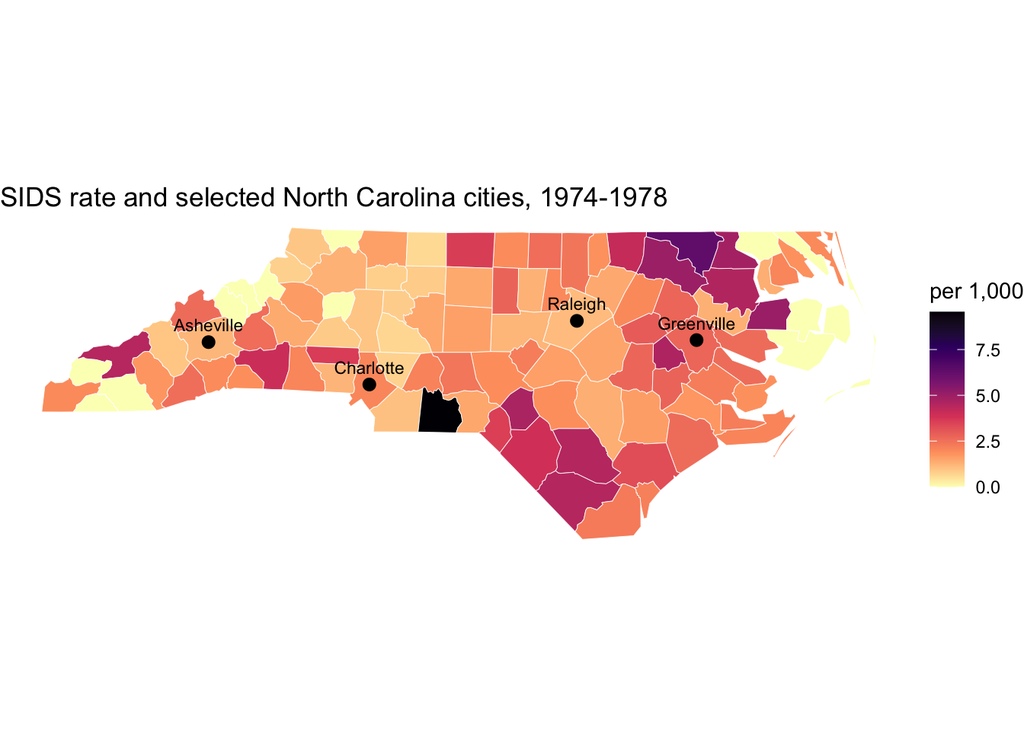

```r
ggplot() +
  geom_sf(data = nc, aes(fill = rate74), colour = "white", linewidth = 0.15) +
  geom_sf(data = cities_sf, size = 2.5, colour = "black") +
  geom_sf_text(data = cities_sf, aes(label = name), size = 3, nudge_y = 0.15) +
  scale_fill_viridis_c(option = "magma", direction = -1, name = "per 1,000") +
  labs(title = "SIDS rate and selected North Carolina cities, 1974-1978") +
  theme_void()
```

The four selected cities are clearly shown on the top of the SIDS rate choropleth, making it easy to compare their locations with the surrounding county-level rates. The points and labels are placed above the polygon layer so the city locations remain visible without obscuring the overall geographic pattern.

4. One sentence: what would go wrong if you built the `sf` object with the coordinate columns in the other order? If the longitude and latitude were reversed, the cities would be assigned incorrect coordinates and would be plotted in the wrong locations instead of within North Carolina. —

## I used ChatGPT to help debug R code and interpret parts of the assignment that I initially had trouble understanding. I wrote out each section of code and the explanations myself while reviewing lecture notes. I also ran the final code to make sure everything ran smoothly and worked correctly.

## Rubric

| Part | What is assessed | Points |
| --- | --- | --- |
| **A** | Correct inspection of the object; clear, accurate answers | 2 |
| **B** | Correct transformation and areas; comparison explained | 2 |
| **C** | Both packages working; counts-vs-rates argument; class intervals compared and a defended choice; cartographic standards met | 5 |
| **D** | Point layer built with the right CRS and correctly overlaid | 2 |
| **E** | Renders from a clean session; AI use note present | 1 |
|  | **Total** | **12** |

Writing counts for roughly 10% of the mark within each part: the prose should be in complete sentences and free of obvious errors. Every part asks for interpretation as well as code — a submission that is all code and no sentences cannot score above about 60%.

## Getting help

- Office hours, or email me — with the code and the exact error message, not a screenshot of the whole console.
- The `sf` documentation is genuinely good: `vignette("sf1", package = "sf")`.
- Moraga Chapter 2 covers most of Parts A–C.
- If you are stuck for more than about thirty minutes on something that feels mechanical, that is a signal to ask rather than to persevere.